# Modello Statistico per Prevedere il Peso dei Neonati

### Conclusioni e considerazioni finali sul modello prodotto

Rappresentare questo modello in un unico grafico è pressochè impossibile condierato il numero di regressori da cui è formato. Per dare un’idea delle relazioni tra i singoli regressori utilizzati e la variabile esplicativa Peso sono stati realizzati 4 scatter plot, uno per ogni variabile quantitativa utilizzata nel modello.

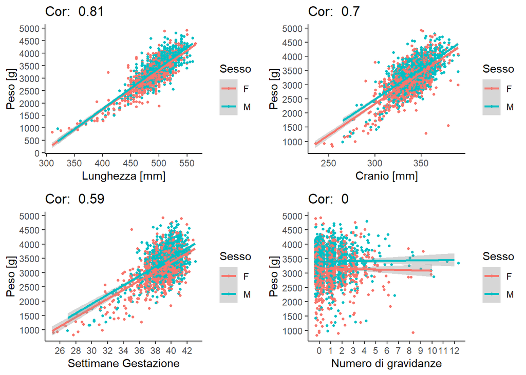

```r
tit = paste('Cor: ',as.character(round(cor(new_data$Peso, new_data$Lunghezza),2)))
g_lun= ggplot(data = new_data)+
  geom_point(aes(Lunghezza,Peso, col=Sesso), pch = 20, position = 'jitter')+
  geom_smooth(aes(Lunghezza,Peso, col=Sesso), method = 'lm')+
  theme_classic()+
  scale_y_continuous(breaks = seq(0,6000,500))+
  scale_x_continuous(breaks = seq(0,600,50))+
  labs(x = 'Lunghezza [mm]',
       y = 'Peso [g]',
       title = tit)

tit = paste('Cor: ',as.character(round(cor(new_data$Peso, new_data$Cranio),2)))
g_cra=ggplot(data = new_data)+
  geom_point(aes(Cranio,Peso, col=Sesso), pch = 20, position = 'jitter')+
  geom_smooth(aes(Cranio,Peso, col=Sesso), method = 'lm')+
  theme_classic()+
  scale_y_continuous(breaks = seq(0,6000,500))+
  scale_x_continuous(breaks = seq(0,600,50))+
  labs(x = 'Cranio [mm]',
       y = 'Peso [g]',
       title = tit)

tit = paste('Cor: ',as.character(round(cor(new_data$Peso, new_data$N.gravidanze),2)))
g_grav=ggplot(data = new_data)+
  geom_point(aes(N.gravidanze,Peso, col=Sesso), pch = 20, position = 'jitter')+
  geom_smooth(aes(N.gravidanze,Peso, col=Sesso), method = 'lm')+
  theme_classic()+
  scale_y_continuous(breaks = seq(0,6000,500))+
  scale_x_continuous(breaks = seq(0,15,1))+
  labs(x = 'Numero di gravidanze',
       y = 'Peso [g]',
       title = tit)

tit = paste('Cor: ',as.character(round(cor(new_data$Peso, new_data$Gestazione),2)))
g_gest=ggplot(data = new_data)+
  geom_point(aes(Gestazione,Peso, col=Sesso), pch = 20, position = 'jitter')+
  geom_smooth(aes(Gestazione,Peso, col=Sesso), method = 'lm')+
  theme_classic()+
  scale_y_continuous(breaks = seq(0,6000,500))+
  scale_x_continuous(breaks = seq(0,50,2))+
  labs(x = 'Settimane Gestazione',
       y = 'Peso [g]',
       title = tit)

library(gridExtra)
grid.arrange(g_lun,g_cra,g_gest,g_grav, nrow=2,ncol=2)
```

In ogni scatter plot è rappresentata la divisione per Sesso, visto che sia dall’analisi dei coefficienti del modello sia dai test di ipotesi svolti, si è notato come le variabili mostrino differenze signifative tra maschi e femmine. Per ciascuna variabile, inoltre, è stato riportato il valore del coefficiente di correlazione lineare con il peso, si nota come la lunghezza sia la variabile con la correlazione maggiore, pari a 0.81. Il numero di gravidanze non mostra correlazione con il peso, tuttavia, dall’analisi dei coefficienti questa variabile è risultata significativa per cui è stata considerata nel modello.

## Modello di previsione Peso

Si vuole fare una previsione del peso di una neonata conoscendo la settimana in cui partirirà la madre e il numero di gravidanze. E’ stato quindi creato un nuovo modello che mettesse in relazione la variabile Peso con le variabili N.gravidanze, Gestazione e Sesso.

Si è partiti considerando esclusivamente gli effetti lineari per poi aggiungere termini quadratici e termini di interazione tra le variabili.

```r
mod_anni_sett = lm(Peso ~ N.gravidanze + Gestazione + Sesso)
summary(mod_anni_sett)
```

```
##
## Call:
## lm(formula = Peso ~ N.gravidanze + Gestazione + Sesso)
##
## Residuals:
##      Min       1Q   Median       3Q      Max
## -1494.15  -272.82   -14.43   267.31  1892.39
##
## Coefficients:
##               Estimate Std. Error t value Pr(>|t|)
## (Intercept)  -3136.835    175.410 -17.883  < 2e-16 ***
## N.gravidanze    23.395      6.509   3.595 0.000331 ***
## Gestazione     162.025      4.499  36.014  < 2e-16 ***
## SessoM         165.144     16.729   9.872  < 2e-16 ***
## ---
## Signif. codes:  0 '***' 0.001 '**' 0.01 '*' 0.05 '.' 0.1 ' ' 1
##
## Residual standard error: 414.2 on 2496 degrees of freedom
## Multiple R-squared:  0.3784, Adjusted R-squared:  0.3777
## F-statistic: 506.5 on 3 and 2496 DF,  p-value: < 2.2e-16
```

```r
mod_anni_sett_1 = update(mod_anni_sett, ~.+ I(Gestazione^2)+I(N.gravidanze^2))
summary(mod_anni_sett_1)
```

```
##
## Call:
## lm(formula = Peso ~ N.gravidanze + Gestazione + Sesso + I(Gestazione^2) +
##     I(N.gravidanze^2))
##
## Residuals:
##      Min       1Q   Median       3Q      Max
## -1487.53  -272.40   -18.23   260.74  1864.78
##
## Coefficients:
##                     Estimate Std. Error t value Pr(>|t|)
## (Intercept)       -1.252e+04  1.323e+03  -9.460  < 2e-16 ***
## N.gravidanze       5.590e+01  1.198e+01   4.666 3.24e-06 ***
## Gestazione         6.694e+02  7.138e+01   9.377  < 2e-16 ***
## SessoM             1.713e+02  1.654e+01  10.353  < 2e-16 ***
## I(Gestazione^2)   -6.840e+00  9.622e-01  -7.108 1.53e-12 ***
## I(N.gravidanze^2) -6.416e+00  1.942e+00  -3.303 0.000969 ***
## ---
## Signif. codes:  0 '***' 0.001 '**' 0.01 '*' 0.05 '.' 0.1 ' ' 1
##
## Residual standard error: 409 on 2494 degrees of freedom
## Multiple R-squared:  0.3944, Adjusted R-squared:  0.3932
## F-statistic: 324.8 on 5 and 2494 DF,  p-value: < 2.2e-16
```

```r
mod_anni_sett_2 = update(mod_anni_sett_1, ~.+ N.gravidanze*Gestazione +
                           N.gravidanze*Sesso + Gestazione*Sesso)
summary(mod_anni_sett_2)
```

```
##
## Call:
## lm(formula = Peso ~ N.gravidanze + Gestazione + Sesso + I(Gestazione^2) +
##     I(N.gravidanze^2) + N.gravidanze:Gestazione + N.gravidanze:Sesso +
##     Gestazione:Sesso)
##
## Residuals:
##      Min       1Q   Median       3Q      Max
## -1510.69  -272.40   -18.14   260.83  1830.52
##
## Coefficients:
##                           Estimate Std. Error t value Pr(>|t|)
## (Intercept)             -1.292e+04  1.356e+03  -9.525  < 2e-16 ***
## N.gravidanze             1.094e+02  1.070e+02   1.023 0.306547
## Gestazione               6.981e+02  7.316e+01   9.542  < 2e-16 ***
## SessoM                  -5.565e+02  3.620e+02  -1.537 0.124401
## I(Gestazione^2)         -7.309e+00  9.906e-01  -7.379 2.17e-13 ***
## I(N.gravidanze^2)       -6.644e+00  1.966e+00  -3.380 0.000736 ***
## N.gravidanze:Gestazione -1.449e+00  2.770e+00  -0.523 0.600993
## N.gravidanze:SessoM      6.847e+00  1.338e+01   0.512 0.608990
## Gestazione:SessoM        1.849e+01  9.230e+00   2.004 0.045230 *
## ---
## Signif. codes:  0 '***' 0.001 '**' 0.01 '*' 0.05 '.' 0.1 ' ' 1
##
## Residual standard error: 408.9 on 2491 degrees of freedom
## Multiple R-squared:  0.3954, Adjusted R-squared:  0.3935
## F-statistic: 203.7 on 8 and 2491 DF,  p-value: < 2.2e-16
```

```r
mod_anni_sett_3 = update(mod_anni_sett_1, ~.+ N.gravidanze*Gestazione)
summary(mod_anni_sett_3)
```

```
##
## Call:
## lm(formula = Peso ~ N.gravidanze + Gestazione + Sesso + I(Gestazione^2) +
##     I(N.gravidanze^2) + N.gravidanze:Gestazione)
##
## Residuals:
##      Min       1Q   Median       3Q      Max
## -1486.89  -272.23   -18.64   261.94  1853.60
##
## Coefficients:
##                           Estimate Std. Error t value Pr(>|t|)
## (Intercept)             -1.262e+04  1.349e+03  -9.356  < 2e-16 ***
## N.gravidanze             9.730e+01  1.054e+02   0.923 0.356147
## Gestazione               6.735e+02  7.217e+01   9.333  < 2e-16 ***
## SessoM                   1.713e+02  1.654e+01  10.355  < 2e-16 ***
## I(Gestazione^2)         -6.879e+00  9.675e-01  -7.110 1.51e-12 ***
## I(N.gravidanze^2)       -6.414e+00  1.943e+00  -3.302 0.000974 ***
## N.gravidanze:Gestazione -1.068e+00  2.701e+00  -0.395 0.692669
## ---
## Signif. codes:  0 '***' 0.001 '**' 0.01 '*' 0.05 '.' 0.1 ' ' 1
##
## Residual standard error: 409.1 on 2493 degrees of freedom
## Multiple R-squared:  0.3944, Adjusted R-squared:  0.393
## F-statistic: 270.6 on 6 and 2493 DF,  p-value: < 2.2e-16
```

```r
mod_anni_sett_4 = update(mod_anni_sett_1, ~.+ N.gravidanze*Sesso)
summary(mod_anni_sett_4)
```

```
##
## Call:
## lm(formula = Peso ~ N.gravidanze + Gestazione + Sesso + I(Gestazione^2) +
##     I(N.gravidanze^2) + N.gravidanze:Sesso)
##
## Residuals:
##      Min       1Q   Median       3Q      Max
## -1487.59  -272.54   -17.73   259.91  1868.65
##
## Coefficients:
##                       Estimate Std. Error t value Pr(>|t|)
## (Intercept)         -1.251e+04  1.324e+03  -9.448  < 2e-16 ***
## N.gravidanze         5.485e+01  1.319e+01   4.159 3.30e-05 ***
## Gestazione           6.690e+02  7.141e+01   9.369  < 2e-16 ***
## SessoM               1.689e+02  2.082e+01   8.111 7.82e-16 ***
## I(Gestazione^2)     -6.836e+00  9.626e-01  -7.101 1.61e-12 ***
## I(N.gravidanze^2)   -6.471e+00  1.964e+00  -3.294    0.001 ***
## N.gravidanze:SessoM  2.466e+00  1.297e+01   0.190    0.849
## ---
## Signif. codes:  0 '***' 0.001 '**' 0.01 '*' 0.05 '.' 0.1 ' ' 1
##
## Residual standard error: 409.1 on 2493 degrees of freedom
## Multiple R-squared:  0.3944, Adjusted R-squared:  0.393
## F-statistic: 270.6 on 6 and 2493 DF,  p-value: < 2.2e-16
```

```r
mod_anni_sett_5 = update(mod_anni_sett_1, ~.+ Sesso*Gestazione)
summary(mod_anni_sett_5)
```

```
##
## Call:
## lm(formula = Peso ~ N.gravidanze + Gestazione + Sesso + I(Gestazione^2) +
##     I(N.gravidanze^2) + Gestazione:Sesso)
##
## Residuals:
##      Min       1Q   Median       3Q      Max
## -1510.62  -271.54   -17.64   261.22  1835.90
##
## Coefficients:
##                     Estimate Std. Error t value Pr(>|t|)
## (Intercept)       -1.279e+04  1.330e+03  -9.618  < 2e-16 ***
## N.gravidanze       5.612e+01  1.197e+01   4.687 2.93e-06 ***
## Gestazione         6.925e+02  7.232e+01   9.576  < 2e-16 ***
## SessoM            -5.270e+02  3.578e+02  -1.473 0.140926
## I(Gestazione^2)   -7.253e+00  9.847e-01  -7.366 2.38e-13 ***
## I(N.gravidanze^2) -6.491e+00  1.942e+00  -3.343 0.000841 ***
## Gestazione:SessoM  1.790e+01  9.165e+00   1.953 0.050873 .
## ---
## Signif. codes:  0 '***' 0.001 '**' 0.01 '*' 0.05 '.' 0.1 ' ' 1
##
## Residual standard error: 408.8 on 2493 degrees of freedom
## Multiple R-squared:  0.3953, Adjusted R-squared:  0.3939
## F-statistic: 271.6 on 6 and 2493 DF,  p-value: < 2.2e-16
```

```r
df=BIC(mod_anni_sett, mod_anni_sett_1)
aic = AIC(mod_anni_sett, mod_anni_sett_1)
df$AIC = aic$AIC
df
```

```
##                 df      BIC      AIC
## mod_anni_sett    5 37261.52 37232.40
## mod_anni_sett_1  7 37211.98 37171.21
```

```r
anova(mod_anni_sett, mod_anni_sett_1)
```

```
## Analysis of Variance Table
##
## Model 1: Peso ~ N.gravidanze + Gestazione + Sesso
## Model 2: Peso ~ N.gravidanze + Gestazione + Sesso + I(Gestazione^2) +
##     I(N.gravidanze^2)
##   Res.Df       RSS Df Sum of Sq      F    Pr(>F)
## 1   2496 428211618
## 2   2494 417190245  2  11021373 32.943 7.561e-15 ***
## ---
## Signif. codes:  0 '***' 0.001 '**' 0.01 '*' 0.05 '.' 0.1 ' ' 1
```

Confrantando il primo modello con quello in cui sono state aggiunte i termini quadratici si nota come quest’ultimo abbia un R-squared adjusted maggiore e indici BIC e AIC minori. Queste considerazioni unite al p-value restituito dal test ANOVA hanno fatto prefirire il secondo modello al primo. L’aggiunta dei termini di interazione non ha portato buoni risultati in quanto questi sono spesso risultati non significativi oppure hanno fatto perdere la significatività a variabili che nel modello di partenza ce l’avevano. Per questa ragione è stato scelto di non includere termini di interazione nel modello utilizzato per la previsione.

```r
pred = data.frame( N.gravidanze = 3,
                   Gestazione = 39,
                   Sesso = 'F')
round(predict(mod_anni_sett_1,newdata = pred),0)
```

```
##    1
## 3297
```

Il peso predetto per una neonata la cui madre è alla terza gravidanza e partorirà alla 39° settimana è di 3297g. Il modello, tuttavia, riesce a spigare solo circa il 40% della varianza della variabile peso per cui non è molto adatto per fornire una previsione accurata.